# QDM – R Style

## Introduction

The following sections will help orient you to R. If you are already familiar, feel free to ignore me for the next couple of minutes or even the remainder of class (no judgment here).

### Basics

Remember the following points:

1. R is case sensitive.
2. If you want to keep something assign it (e.g., objectName = 1:5).
3. Everything (e.g., parentheses, brackets) needs to be closed.

### Package Installation

R is not just one thing, but a collection of packages (kind of how Excel has add-ins, but R is cooler). If we want to add packages to our R installation, we will run the following line of code:

```r
install.packages(c("tidyverse", "simmer", "lpSolve", "lpSolveAPI"))
```

You will only need to run this once, unless you update your R installation.

Once you have installed a package, you will need to load it to be able to use it.

```r
library(simmer)
```

### Objects & Functions

In R, everything is an object. What does that mean? Let’s think about a typical table. That table is an object. Not only is that table an object, but every “cell” within that table is also an object. This means that we can do almost anything we want to any object within our environment.

Here is an example:

Let’s take this table:

```r
testDF = data.frame(id = 1:5,
                    score = sample(1:5, 5, replace = TRUE))

testDF
```

```
##   id score
## 1  1     3
## 2  2     3
## 3  3     4
## 4  4     3
## 5  5     3
```

With our table, we could do many different things to it. Since we are talking about working with objects, let’s tweak an individual object.

```r
testDF$score[3] = mean(testDF$score)

testDF
```

```
##   id score
## 1  1   3.0
## 2  2   3.0
## 3  3   3.2
## 4  4   3.0
## 5  5   3.0
```

We found the 3rd row of the score variable within our data and replaced it with the mean of every score.

### Why?

If this is your first foray into R and/or programming, you might be asking yourself why in the name of god would you ever choose to do this to yourself.

There are many reasons. Perhaps the most important is literacy. Open-source statistical computing is not the future – it is the now. The traditional packages are neither on the cutting nor the bleeding edge. Being able to communicate with people “out there” about such matters is important (knowing more R than most people landed me my first job).

Another reason is pure utility. Learning just a little bit of statistical programming can help you do things you never thought possible. Maybe you have a decision to make (e.g., you and your friend/SO/etc. cannot decide on what to eat). You can do something like the following:

```r
decision = sample(c("thai", "pizza"), 100000, replace = TRUE)

c(thai = length(decision[decision == "thai"]), pizza = length(decision[decision == "pizza"]))
```

```
##  thai pizza
## 50045 49955
```

This is nearing into Monte Carlo stuff!

The content of this course does not allow us to stray much, but some of these techniques won’t solve our problems. Using R (or Python) will let us to create solutions to some really tricky problems.

## QDM Topics

The following tabs will provide details on conducting our models in R.

### Process Simulation

Process simulation in R is handled with the *simmer* package.

NOTE: We may not be able to install *simmer* on the machines in the classroom because we need Rtools installed.

```r
library(simmer)
```

That was the easy part.

We are going to play around with the bank example.

```r
set.seed(1269)

customer = trajectory("Customer's path") %>%
  set_attribute("start_time", function() {now(bank)}) %>%
  seize("counter") %>%
  timeout(function() {rexp(1, 1/12)}) %>%
  release("counter")

bank = simmer("bank") %>%
  add_resource("counter") %>%
  add_generator("Customer", customer, function() {c(0, rexp(49, 1/10), -1)})

bank %>% run(until = 480)
```

```
## simmer environment: bank | now: 480 | next: 499.703416435746
## { Resource: counter | monitored: TRUE | server status: 1(1) | queue status: 21(Inf) }
## { Generator: Customer | monitored: 1 | n_generated: 50 }
```

```r
bank %>%
  get_mon_arrivals %>%
  dplyr::mutate(waiting_time = end_time - start_time - activity_time) %>%
  DT::datatable()
```

|  | name | start_time | end_time | activity_time | finished | replication | waiting_time |
| --- | --- | --- | --- | --- | --- | --- | --- |
| 1 | Customer0 | 0 | 3.90119972079992 | 3.90119972079992 | True | 1 | 0 |
| 2 | Customer1 | 3.68364776019007 | 22.5743520622304 | 18.6731523414305 | True | 1 | 0.217551960609853 |
| 3 | Customer2 | 3.8952900838434 | 26.128133932983 | 3.55378187075257 | True | 1 | 18.679061978387 |
| 4 | Customer3 | 10.9609634607882 | 35.6410558134095 | 9.51292188042655 | True | 1 | 15.1671704721948 |
| 5 | Customer4 | 12.4143378522099 | 38.5666859023051 | 2.92563008889556 | True | 1 | 23.2267179611997 |
| 6 | Customer5 | 16.5103502120018 | 63.6906589356391 | 25.123973033334 | True | 1 | 22.0563356903033 |
| 7 | Customer6 | 29.960323517269 | 99.2671135432551 | 35.576454607616 | True | 1 | 33.7303354183701 |
| 8 | Customer7 | 66.8406301725722 | 137.450895500766 | 38.1837819575109 | True | 1 | 32.4264833706828 |
| 9 | Customer8 | 79.1754666223371 | 153.772080805976 | 16.3211853052105 | True | 1 | 58.2754288784289 |
| 10 | Customer9 | 90.5214631992096 | 170.720712618032 | 16.9486318120555 | True | 1 | 63.2506176067668 |

[output cut: 18 more lines]

```r
bank %>%
  get_mon_resources %>%
  DT::datatable()
```

|  | resource | time | server | queue | capacity | queue_size | system | limit | replication |
| --- | --- | --- | --- | --- | --- | --- | --- | --- | --- |
| 1 | counter | 0 | 1 | 0 | 1 |  | 1 |  | 1 |
| 2 | counter | 3.68364776019007 | 1 | 1 | 1 |  | 2 |  | 1 |
| 3 | counter | 3.8952900838434 | 1 | 2 | 1 |  | 3 |  | 1 |
| 4 | counter | 3.90119972079992 | 1 | 1 | 1 |  | 2 |  | 1 |
| 5 | counter | 10.9609634607882 | 1 | 2 | 1 |  | 3 |  | 1 |
| 6 | counter | 12.4143378522099 | 1 | 3 | 1 |  | 4 |  | 1 |
| 7 | counter | 16.5103502120018 | 1 | 4 | 1 |  | 5 |  | 1 |
| 8 | counter | 22.5743520622304 | 1 | 3 | 1 |  | 4 |  | 1 |
| 9 | counter | 26.128133932983 | 1 | 2 | 1 |  | 3 |  | 1 |
| 10 | counter | 29.960323517269 | 1 | 3 | 1 |  | 4 |  | 1 |

[output cut: 68 more lines]

You will notice that we have only been doing one run and we know the dangers that can come along with that.

```r
library(parallel)

customer = trajectory("Customer's path") %>%
  seize("counter") %>%
  timeout(function() {rexp(1, 1/12)}) %>%
  release("counter")

mclapply(c(sample(1:100000000, 20)), function(the_seed) {
  set.seed(the_seed)

  bank = simmer("bank") %>%
    add_resource("counter", 1) %>%
    add_generator("Customer", customer, function() {c(0, rexp(49, 1/10), -1)})

  bank %>% run(until = 480)

  result = bank %>%
    get_mon_arrivals %>%
    dplyr::mutate(waiting_time = end_time - start_time - activity_time)
  paste("Average wait for ", sum(result$finished), " completions was ",
        mean(result$waiting_time), " minutes.", sep = "")
}) %>%
  unlist()
```

```
##  [1] "Average wait for 34 completions was 72.6396294637723 minutes."
##  [2] "Average wait for 36 completions was 14.5315902384022 minutes."
##  [3] "Average wait for 31 completions was 65.9075466486259 minutes."
##  [4] "Average wait for 40 completions was 41.9304798947267 minutes."
##  [5] "Average wait for 22 completions was 162.975771027556 minutes."
##  [6] "Average wait for 35 completions was 43.345584911687 minutes."
##  [7] "Average wait for 29 completions was 82.0612306544724 minutes."
##  [8] "Average wait for 35 completions was 84.4037033569697 minutes."
##  [9] "Average wait for 37 completions was 60.8868644752746 minutes."
## [10] "Average wait for 37 completions was 117.784187920133 minutes."
## [11] "Average wait for 48 completions was 83.7526949819617 minutes."
## [12] "Average wait for 36 completions was 102.853460644648 minutes."
## [13] "Average wait for 35 completions was 72.8217238058589 minutes."
## [14] "Average wait for 16 completions was 86.9815440938896 minutes."
## [15] "Average wait for 39 completions was 96.798919596644 minutes."
## [16] "Average wait for 37 completions was 72.8803746827611 minutes."
## [17] "Average wait for 37 completions was 95.1787051005785 minutes."
## [18] "Average wait for 35 completions was 20.3750844817741 minutes."
## [19] "Average wait for 44 completions was 62.0290328941782 minutes."
## [20] "Average wait for 31 completions was 9.52090319925886 minutes."
```

We also have branch(), renege(), and several others.

### Linear Programming

In all matters of linear programming, we do have some options in R. For our demonstrations, we will be using *lpSolveAPI*. It and *lpSolve* are likely the most-used packages for linear programming in R.

```r
library(lpSolveAPI)

train = data.frame(wagon = c('w1','w2','w3'),
                   weightcapacity = c(10, 8, 12),
                   spacecapacity = c(5000, 4000, 8000))

cargo = data.frame(type = c('c1','c2','c3','c4'),
                   available = c(18, 10, 5, 20),
                   volume = c(400, 300, 200, 500),
                   profit = c(2000, 2500, 5000, 3500))

lpModel = make.lp((2 * NROW(train)) + NROW(cargo), 12)

column = 0

row = 0

# build the model column per column
for(wg in train$wagon) {
  row = row + 1

  for(type in seq(1, NROW(cargo$type))){

    column = column + 1

    set.column(lpModel, column, c(1, cargo[type,'volume'], 1),
               indices = c(row, NROW(train) + row, NROW(train) * 2 + type))
  }}

# set rhs weight constraints
set.constr.value(lpModel, rhs = train$weightcapacity,
                 constraints = seq(1, NROW(train)))

# set rhs volume constraints
set.constr.value(lpModel, rhs = train$spacecapacity,
                 constraints = seq((NROW(train) + 1), (NROW(train) * 2)))

# set rhs volume constraints
set.constr.value(lpModel, rhs = cargo$available,
                 constraints = seq((NROW(train) * 2) + 1, (NROW(train) * 2) + NROW(cargo)))

# set objective coefficients
set.objfn(lpModel, rep(cargo$profit, NROW(train)))

# set objective direction
lp.control(lpModel, sense = 'max')
```

[output not shown]

[output cut: 12 more lines]

[output not shown]

```r
# In order to be able to visually check the model.
write.lp(lpModel, 'model.lp', type = 'lp')

solve(lpModel)
```

```
## [1] 0
```

```r
# This will return the proposed solution
get.objective(lpModel)
```

```
## [1] 107500
```

```r
# Through magic, this will return our decision variables
get.constraints(lpModel)
```

```
##  [1]   10    8   12 2500 4000 6000    0    5    5   20
```

We could use the set.type() function to turn this into an integer programming problem if needed.

### Risk Analysis

You might recall in my ramblings about @Risk that risk analyis is nothing more than Monte Carlo simulations. We can tackle this in many different ways.

Let’s start with a simple example of Monte Carlo simulation. The folks in UX research always talk about A/B testing. Let’s suppose we have two different UIs and we want to test whether one will “cause” an increase in subscriptions. In our bit of testing, we have shown 100 people *A* and 110 people *B* – 20 people subscribed after viewing *A* and 38 people subscribed after viewing *B*. While some people might be satisfied with a *t*-test, we will do something a bit different (an important aside is that this would not be a standard *t*-test, because of our imbalance – we would need to use Welsch’s test instead).

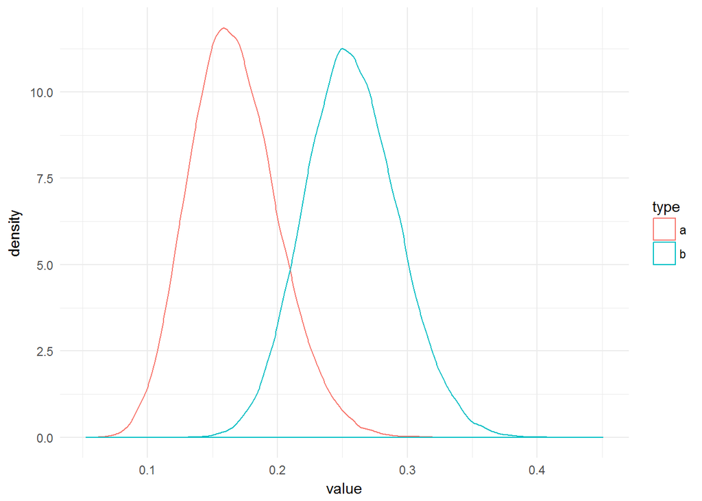

```r
runs = 100000

aSamples = rbeta(runs, 20, 100)

bSamples = rbeta(runs, 38, 110)

dat = data.frame(type = rep(c("a", "b"), each = runs),
                 value = c(aSamples, bSamples))

library(ggplot2)
ggplot(dat, aes(x = value, color = type)) +
  geom_density() +
  theme_minimal()
```

```r
mcPValue = sum(aSamples > bSamples)/runs
```

Now that we have our bearings about us with regard to Monte Carlo, let’s adapt it to risk assessment.

One popular place use of risk assessment is in stock prices. If we assume that a stock opens at $20, we know how it has been performing in the past, we can project out into the future.

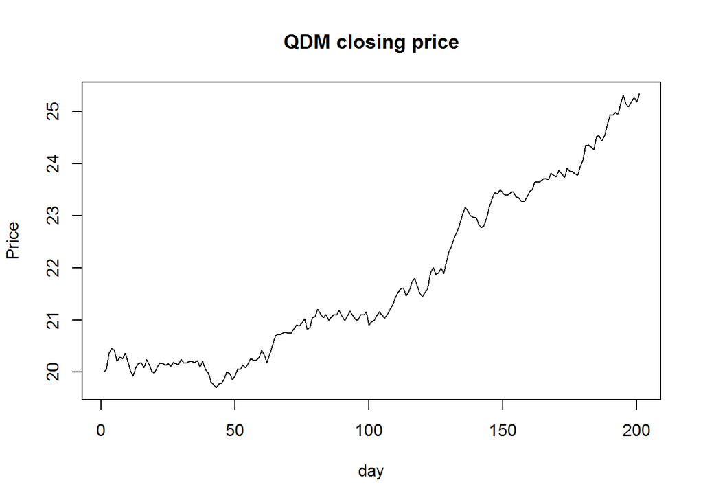

```r
days = 200

changes = rnorm(200, mean = 1.001, sd = 0.005)

plot(cumprod(c(20,changes)), type = 'l', ylab = "Price",
     xlab = "day", main = "QDM closing price")
```

```r
runs = 100000

# simulates future movements and returns the closing price on day 200

generatePath = function(){

  days = 200

  changes = rnorm(200, mean = 1.001, sd = 0.005)

  sample.path = cumprod(c(20, changes))

  closing.price = sample.path[days+1]

  return(closing.price)
}

mcClosing = replicate(runs, generatePath())
```